# author:

# Discussion

These null results have a number of important substantive implications. First, they underscore that it is crucial to recognize the conditional aspects of the classic theory regarding democracy and democratic support. With regard to how levels of democracy affect public support, even the early proponents of the classic argument did not contend that the mere existence of democratic institutions, no matter how consistently feckless and ineffective, would generate support among the public: instead, they maintained, public support would be gained through experience with government performance that was generally effective [@lipset_social_1959, 86-89; @Easton1965, 119-120]. There is some empirical evidence for this, with government effectiveness positively related to public support among democracies and negatively related in non-democracies [@Magalhaes2014]. The finding of @Krieckhaus2014 that income inequality is strongly negatively related to public support in democracies suggests that performance regarding redistribution is particularly important. On the reverse part of the classic argument, @Qi2011 suggests that democratic support alone cannot be expected to generate democratic change and oppose backsliding. Instead, that work contends, it is the combination of democratic support and dissatisfaction with current regime performance that generates demand for greater democracy. Whether these conditional relationships exist among the newly available latent-variable data on democracy and democratic support remain questions for future research.

Further, these null results recommend building recent and more refined conceptualizations of democratic support into our measures. In other words, the survey items employed by Claassen [-@Claassen2020a; -@Claassen2020b]—which ask respondents to assess the desirability or appropriateness of democracy, to compare democracy to some undemocratic alternative, or to assess one of these alternatives—although often used by researchers, may not capture every aspect of democratic support necessary for it to play its hypothesized roles in the classic theory. One possibility is that only those who profess to prefer democracy to its alternatives *and also* value freedom of expression, freedom of association, and pluralism of opinion will take appropriate action when democracy is threatened [see, e.g., @Schedler2007]. Another is that respondents’ other values, such as their policy preferences or partisanship, may weigh more heavily than their support for democracy: there is growing evidence that, at least in the United States, there are many for whom these other considerations excuse substantial transgressions against democracy [see @Carey2020; @graham_democracy_2020; @McCoy2020]. Yet another is that the answers to the above items reflect actual support for democracy only when respondents also either hold a robust understanding of what liberal democracy means or anchor their support in emancipative values of universal freedoms. If they do not, their positive responses to these items indicate support for autocracy instead [see, e.g., @Brunkert2019; @Kirsch2019; @Wuttke2021]. Taking any or all of these into account requires considering the *combination* of attitudes: even the inclusion of additional questions in a unidimensional public opinion model such as that provided by @Claassen2019 will not be sufficient [see, e.g., @Wuttke2020].

Finally, by failing to provide evidence for a short-term relationship between democratic support and democracy, these null findings can be seen to lend additional support to other theories of regime change. There are compelling arguments that episodes of democratic transition [see, e.g., @ODonnell1986a; @Karl1987] and backsliding [see, e.g., @levitsky_how_2018; @Haggard2021] are best understood as products of elite decision making. With regard to the latter, critics have charged that these claims overlook the extent of demand for authoritarian rule among the public [see, e.g., @Norris2021]. The null results reported here, by finding that year-to-year changes in democratic support bear little relationship to changes in democracy, highlight that levels of public support appear to relate to regime only over the long run [see also @Welzel2017], leaving elite decisions as a powerful explanation for when and how short-term developments unfold.

# Conclusion

In this letter, we reexamined the findings from Claassen [-@Claassen2020a; -@Claassen2020b], two articles that maintain that public support helps the survival of democracy and democratic development has a thermostatic effect on public support. We demonstrated the importance of incorporating measurement uncertainty in analyzing the relationship between public support and democracy. Taking uncertainty into account rendered both articles’ conclusions without empirical support, even when we added a considerable quantity of additional data.

This points to the absolute necessity of incorporating measurement uncertainty into analyses that include latent variables. As the use of latent variables grows more common in political science, both researchers and readers should be aware that these variables’ concomitant measurement uncertainty cannot be neglected.

The null results reached in this letter have several substantive implications. They highlight theoretical arguments that maintain that levels of democratic support undergird democracy only over the long term and so lend indirect support to other explanations for short-run changes in regime. They also draw attention to the conditional nature of the classic argument on democracy and democratic support as well as to challenges in measuring the concept of democratic support that remain unmet by existing time-series cross-sectional latent-variable models. Most importantly, the sanguine assessment that readers may draw from Claassen [-@Claassen2020a; -@Claassen2020b]—that the fate of democracies depend on public support, and when eroded, their publics will rally to them—is not supported by the current evidence. Those who would defend democracy have no grounds to be complacent.

# Online Supplementary Information Appendix

# Replication Notes

Because the Dataverse replication files for @Claassen2020a and @Claassen2020b included only the point estimates of their variables, replicating those articles’ analyses while incorporating the quantified uncertainty in their latent variables was not possible using only those files. Instead, it required re-collecting all of the data employed in those articles directly from their original sources, that is, in the terminology of @Grossman2020, it required a primary replication rather than a secondary one. We describe this process for the latent variables here.

## Democratic Support

First, for each item used in the two articles’ measure of democratic support, we identified the original variable names and corresponding values in each survey dataset. We then used the `dcpo_setup` and `format_claassen` functions of the `DCPOtools` R package to automate the process of generating a dataset of survey marginals. These survey marginals were then used to generate estimates of democratic support in Stan using the `supdem.stan.mod5.stan` script from the @Claassen2020a Dataverse materials. Draws from the posterior distribution quantify the uncertainty in the estimates.

## Democracy

The democracy variables in the two articles are drawn from Version 8 of the V-Dem Dataset [@coppedge2018]. This version of the dataset includes draws from the posterior distribution of the estimates to quantify their uncertainty. In our extension (the rightmost replication of each model in our Figures 1 and 2), we are able to extend the time series beyond the last year of Version 8, 2017, so we use the updated Version 10 instead. Version 10, however, does not include posterior draws of the estimates, but rather standard errors. For the purposes of incorporating this uncertainty into our analyses, we assumed a normal distribution around the point estimates.

## Corruption

The corruption variable used in @Claassen2020b is the Corruption Perceptions Index, which provides point estimates and standard errors for the years from 2012 to 2018. For country-years beyond that range, we estimated standard errors for by first identifying the country’s maximum relative standard error (standard error/point estimate) during 2012-2018 and then multiplying this quantity by the country-year’s point estimate. For the purposes of incorporating this uncertainty into our analyses, we again assumed a normal distribution around the point estimates.

In Appendix @ref(moc), we illustrate how we employed these simulated distributions to take uncertainty into account in our analysis models.

# The Method of Composition

In our analysis models, we have latent variables in both sides of the equations: public democratic support, democracy, and corruption. Since measurement uncertainty associated with these latent variables can propagate into the inferences over coefficient parameters in models, we incorporate uncertainty by employing the “Method of Composition” [@Tanner1993, 52], which has often been applied in analyses with latent variables in political science [see, e.g., @Treier2008; @caughey2018; @Kastellec2015].

As @caughey2018 [A-15] explained, the main idea of MOC is to estimate the marginal distribution of coefficient parameter vector $\beta$, integrating over the uncertainty in latent variables $\theta$. More explicitly, we wish to integrate the joint density of $\beta$ and $\theta$ over the distribution of $\theta$.

$$\begin{equation}
p(\beta,\theta|w,y, Z) = p(\beta|\theta,w,y)p(\theta|Z).
\end{equation}$$

where $\theta$ is latent varibles with measurement errors conditional on data Z and a measurement model, $w$ is other predictors without errors, $Z$ is indicators for latent variables $X$, and $y$ is the outcome variable. In this way, we incorportate uncertainty in measuring predictor $\theta$, and uncertainty in the effects of latent variables $\theta$ and other variables $w$ on outcome variable $y$ [@Treier2008, 215]. To sample from the conditional dentsity and the marginal density in the right side of the equation, we follow iterative Monte Carlo procdure described by @Treier2008, at iteration t,

1. We sample $\theta^{s}$ from its posterior distribution $p(\theta|Z)$ and $y$ from $p(y|Z)$.
2. For each analysis model, we run the model with $y$, $\theta$, and $w$, and save the coefficient estimates $\beta^{s}$ and variance-covariance matrix of $\beta^{s}$, $V^{s}$, both of which change due to the uncertainty in $\theta^{s}$ and $y^{s}$.
3. We sample $\tilde{\beta^{t}}$ from the multivariate normal density with mean vector $\beta{s}$ and variance-covariace matrix $V^{s}$.

We incorporate uncertainty for five variables, public support for democracy, liberal democracy, electoral democracy, the liberal component index, and the corruption perceptions index. For each of these five latent variables, we take 900 draws from its posterior distribution. We duplicate the dataset of variables “without” measurement error 900 times, and assign them to each a different random draw from the distributions of variables with measurement error, which yields 900 dataset. In next step, we run each of analysis models with these 900 datesets independently and save the resulting estimates of coefficients and the matrix of variance-covariance for each run. We then draw one sample from the mulitivariate normal distribution with the mean vector of coefficient estimates and variance-covariance matrix produced from each run. This procedure finally yields 900 samples of estimated coefficients drawn from the joint density of $\beta$ and $\theta$. We calculate point estimates and standard error based on these 900 samples.

# DCPO Replication

To make fuller use of the available survey data, we also replicated the tests of the classic arguments on democracy and public support using the DCPO model put forward in @Solt2020a on our expanded data set. The DCPO model has several advantages over the @Claassen2019 model used in Claassen [-@Claassen2020a; -@Claassen2020b]. First, while the @Claassen2019 model dichotomizes responses and so discards some information provided by 50 of the 52 survey items employed in Claassen [-@Claassen2020a; -@Claassen2020b], the DCPO model makes use of all of the information available from these ordinal items [@Solt2020a, p.5]. Second, as the DCPO model includes both parameters for the dispersion of each survey item and for the standard deviation of aggregate public opinion in each country-year, it is a complete population-level item-response model and so, unlike the @Claassen2019 model, is explicitly derived from an individual-level model of survey responses [@Solt2020a, pp.3-4; see also @McGann2014]. Third, to produce more sensible estimates of uncertainty for observations at the extremes of the scale [see @Linzer2015, 229], the DCPO model places bounds on its estimates of public opinion [@Solt2020a, 8]. Further commending the DCPO model to us—and demonstrating that its advantages make a difference—the validation tests in @Solt2020a [pp.10-12] reveal that it fits survey data on democratic support better than the @Claassen2019 model does.

We employ the superior DCPO model to our expanded dataset using the `DCPO` package for R [@Solt2020b]. We then use the estimated public support from the DCPO model to replicate all of the analyses presented in the text. Figures @ref(fig:plot-dcpoAJPS) and Figures @ref(fig:plot-dcpoAPSR) display these results as the righthand set of results, with the replication of the articles’ original results based only on point estimates on the left and our extension with uncertainty and more data, but the articles’ original, @Claassen2019, model in the middle for comparison.

Even with the advantages of the DCPO model, there is no evidence to support the conclusions of Claassen [-@Claassen2020a; -@Claassen2020b] that public support sustains democratic regimes or public support responds thermostatically to changes in democracy.

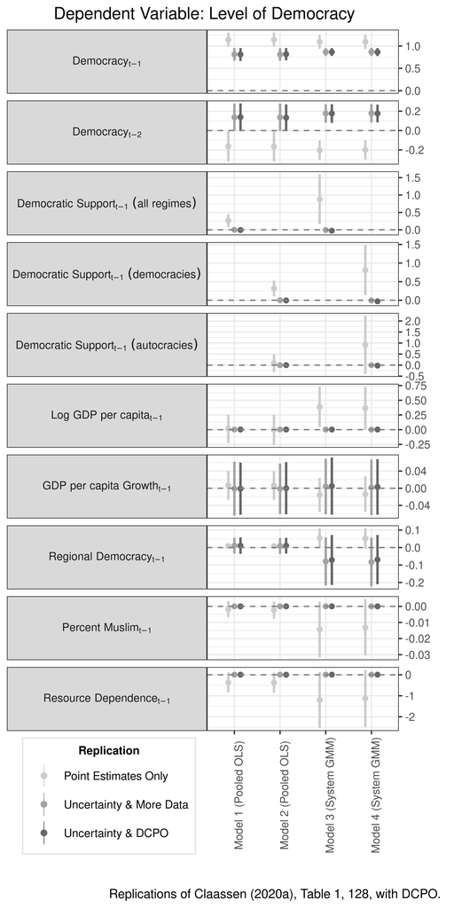

The Effect of Public Support on Democracy

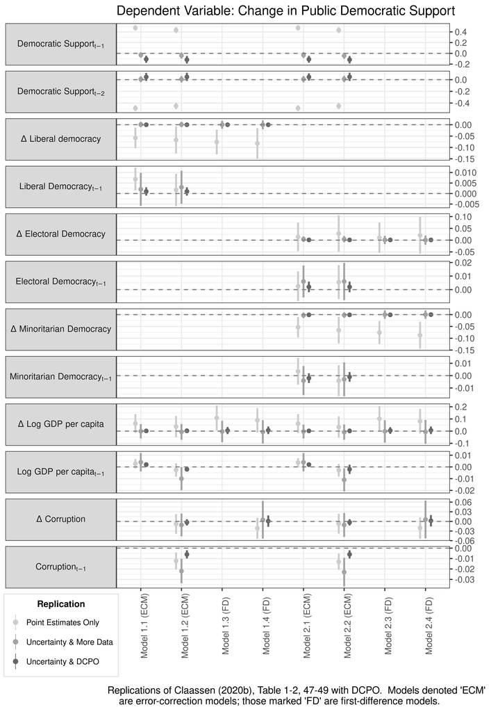

The Effect of Democracy on the Change of Public Support

# References

[^1]: Additional details on this data replication process are found in Supplementary Information Appendix @ref(dgp).
[^2]: We also attempted to make fuller use of the available survey data by employing the DCPO model [@Solt2020a], which unlike the [@Claassen2019] model does not dichotomize ordinal responses. The better fit of the DCPO model to the data on democratic support [see @Solt2020a, 10-12] and the additional information it incorporates, however, did not yield substantively different results; see Supplementary Information Appendix @ref(dcpo).
[^3]: For additional details on this technique, see Supplementary Information Appendix @ref(moc).
[^4]: These figures represent the survey data actually used in estimating public support for democracy; as in Claassen [-@Claassen2020a; -@Claassen2020b], countries for which two separate years of survey data were not available were excluded.